# Inference 2 - Hypothesis Tests

# 1 Contents

This section covers a fundamental part of inference: hypothesis testing.

Tests of hypotheses are frequently applied in econometrics, e.g. t-tests for OLS parameters or in tests for heteroscedasticity.

In this section we will:

- Take a look at the general hypothesis testing procedure
- Derive hypothesis testing with a simulation
- Learn how to do hypothesis testing in R

In the previous part I assumed that we know the population. Actually – in practice – we don’t. We use hypothesis testing because we don’t much about our populations.

**We actually don’t know**:

- The population mean $\mu_X$ (our parameter of interest)
- The population variance $\sigma^2_X$ and standard deviation $\sigma_X$
- The true distribution of the population $X \sim ?(?)$

In this scenario (which is the realistic scenario) we do the following:

1. **Assume the population distribution and a value for our parameter of interest**
2. **Then estimate the unknown parameters from a sample**
3. **Test if our assumptions are reasonable**

# 2 Formal Hypothesis Testing Procedure

Assume that the distribution of the population is normal (e.g. because it is reasonably from theory)

1. Formulate a hypothesis about our population parameter (e.g. $H_0:\mu_X = 1000$) 1.1 Also the alternative hypothesis $H_1: \mu_X \neq 1000$
2. Estimate the parameter
   - In this case with the arithmetic mean $\bar{X}$
3. Estimate the variance and derive the sample standard deviation $S_X$
4. Standardise $\bar{X}$ using our estimated $S_X$ and the assumed $\mu_X$
5. Calculate the probability that our observed $\bar{X}$ is from the population, given a specific level of certainty (e.g. $95 \%$)

# 3 Simulated Population

We take again our sample from a simulated population of ZU student income:

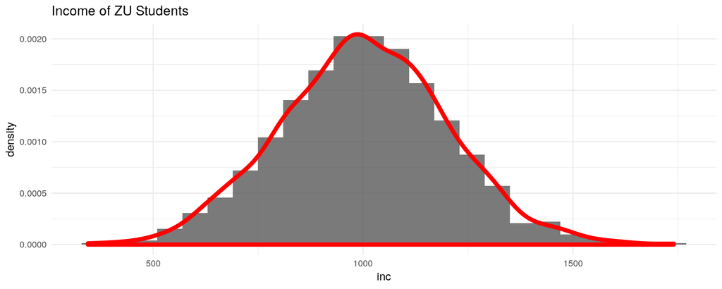

```r
library(ggplot2)
library(tidyverse)
set.seed(11) # seed for reproducibility

n <- 1200
inc <- rnorm(n, mean = 1000, sd = 200)

ggplot() +
geom_histogram(aes(x = inc,
y = ..density..),binwidth = 60,alpha = 0.8) +
geom_density(aes(x = inc,
y = ..density..),col = "red",size = 2,alpha = 0.8) +
labs(title = "Income of ZU Students") +
theme_minimal()
```

## 3.1 Sample

We draw a random sample with size `50` from our population:

```r
set.seed(24)
sample_n <- 50
sample <- sample(x = inc, size = sample_n, replace = F)
```

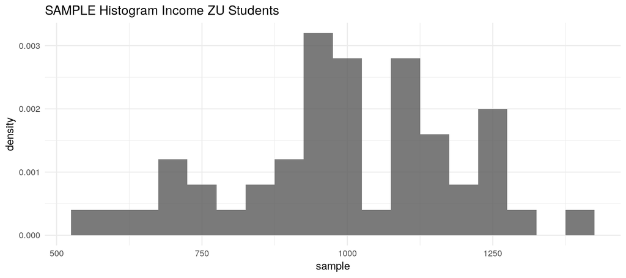

```r
ggplot() +
geom_histogram(aes(x = sample,
y = ..density..),binwidth = 50,alpha = 0.8) +
labs(title = "SAMPLE Histogram Income ZU Students") +
theme_minimal()
```

# 4 Hypothesis Testing Procedure

Given the assumption that our population is distributed normally we:

## 4.1 Formulate the Null-Hypothesis that mean student income is less then $940 €$

$$H_0 : \mu_{inc} < 940$$
Which leaves us with the alternative Hypothesis that the mean income is more or equal to $940€$:
$$H_1: \mu_{inc} \geq 940$$

```r
mu_inc = 940
mu_inc
```

```
## [1] 940
```

## 4.2 Estimate the mean with the sample mean $\bar{X}$

```r
inc_bar <- mean(sample)
inc_bar
```

```
## [1] 998.3979
```

## 4.3 Estimate the sampling standard deviation $S / \sqrt{n}$

```r
S_inc_bar <- sqrt(var(sample)/(sample_n))
S_inc_bar
```

```
## [1] 27.27298
```

At this state we would expect our sample mean to be distributed like this:

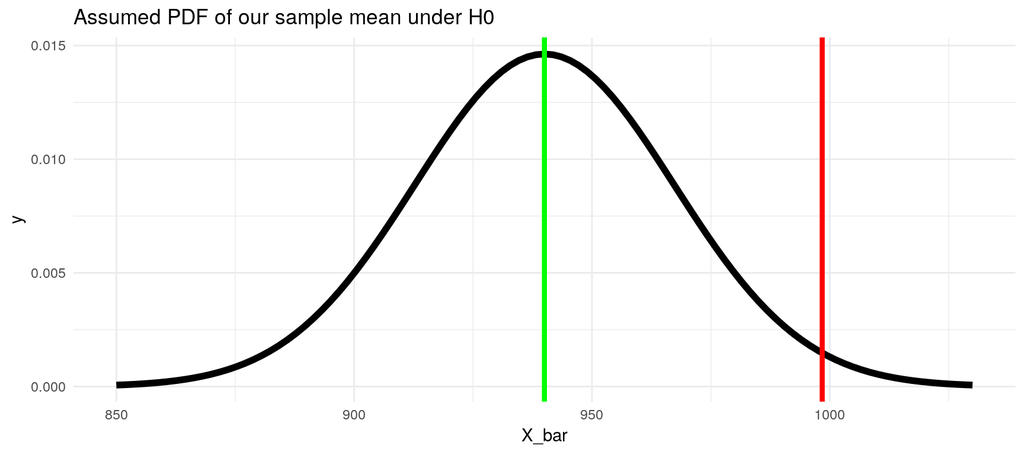

```r
ggplot(data =  data.frame(X_bar = 850:1030), aes(x=X_bar)) +
  stat_function(fun = dnorm, args = list(mean = mu_inc, sd = S_inc_bar), size = 2) +
  geom_vline(xintercept = inc_bar, color = "red", size = 1.5) +
  geom_vline(xintercept = mu_inc, color = "green", size = 1.5) +
  labs(title = "Assumed PDF of our sample mean under H0") +
  theme_minimal()
```

## 4.4 Standardise $\bar{X}$ so we can easily calculate probabilities

```r
Z_inc_bar <- (inc_bar - 940) / (S_inc_bar)
Z_inc_bar
```

```
## [1] 2.141236
```

Our standardised income is also called the *test statistic*.

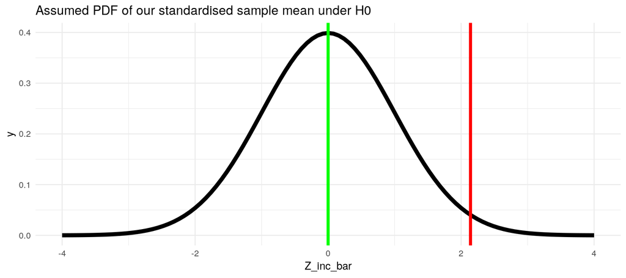

```r
ggplot(data =  data.frame(Z_inc_bar = -4:4), aes(x=Z_inc_bar)) +
  stat_function(fun = dnorm, args = list(mean = 0, sd = 1), size = 2) +
  geom_vline(xintercept = Z_inc_bar, color = "red", size = 1.5) +
  geom_vline(xintercept = 0, color = "green", size = 1.5) +
  labs(title = "Assumed PDF of our standardised sample mean under H0") +
  theme_minimal()
```

## 4.5 Calculate probability of $\bar{X}$ occuring at 5% significance level

Look up the critical $z-value$ for $1-5\% = 95\%$, e.g. in this [table](http://www.z-table.com/).

$$c = z_{95 \%} \approx 1.65$$

Or in R:

```r
qnorm(0.95)
```

```
## [1] 1.644854
```

Lets visualise this:

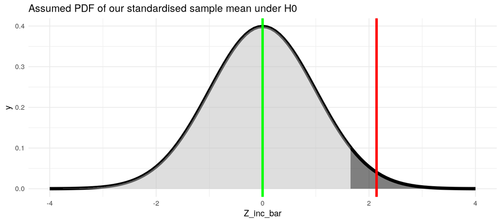

```r
ggplot(data =  data.frame(Z_inc_bar = -4:4), aes(x=Z_inc_bar)) +
  stat_function(fun = dnorm, args = list(mean = 0, sd = 1), size = 2) +
    stat_function(fun = dnorm, xlim = c(-4,1.65), geom = "area", fill = "grey", alpha=0.5) +
  stat_function(fun = dnorm, xlim = c(1.65,4), geom = "area", fill = "black", alpha=0.5) +
  geom_vline(xintercept = Z_inc_bar, color = "red", size = 1.5) +
  geom_vline(xintercept = 0, color = "green", size = 1.5) +
  labs(title = "Assumed PDF of our standardised sample mean under H0") +
  theme_minimal()
```

### 4.5.1 Hypothesis Test:

Check whether our standardised estimator $Z_{\bar{inc}}$ is larger than our critical value $c$.

Remember our $H_0: \mu_{inc} < 940€$ and $H_1: \mu_{inc} \geq 940€$. Lets test that in R:

```r
Z_inc_bar >= qnorm(0.95)
```

```
## [1] TRUE
```

We now can make the following statements:

- If the $H_0$ is true, samples with a $Z_\bar{inc}$ in the dark grey area only occur $5\%$ of the time
  - We call that area the rejection region
- We showed that our observed sample mean (in standardised form) falls into the rejection region
- In conclusion, we have some evidence against our initial assumption that mean student income is at most $940 €$
- This means that we can be optimistic that our sample is not one of the $5 \%$ of outliers in the world of $H_0$, but that the $H_0$ is wrong

Generally we can make the statement: “we can reject the null hypothesis that mean ZU student income is less than $940€$ at a significance level of $5\%$”

### 4.5.2 Hypothesis Test - Other Possible Variants

What we did was only the *right-sided* hypothesis test.

We could also test other hypotheses:

- Left-sided: $H_0: \mu_{inc} > 940€$ and $H_1: \mu_{inc} \leq 940€$
  - Test: $\mu_{inc} \leq c$
- Both-sided: $H_0: \mu_{inc} = 940€$ and $H_1: \mu_{inc} \neq 940€$
  - Test :$|\mu_{inc}| > c$

## 4.6 P-Values

In our example, we could not only reject the $H_0$ at the $5\%$ level, but also at the $2.5\%$ level:

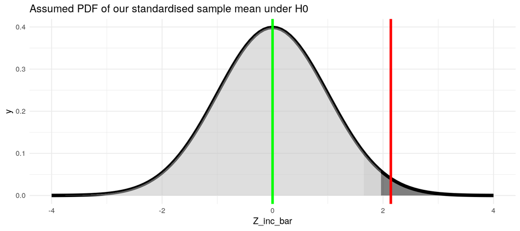

```r
ggplot(data =  data.frame(Z_inc_bar = -4:4), aes(x=Z_inc_bar)) +
  stat_function(fun = dnorm, args = list(mean = 0, sd = 1), size = 2) +
    stat_function(fun = dnorm, xlim = c(-4,1.65), geom = "area", fill = "grey", alpha=0.5) +
  stat_function(fun = dnorm, xlim = c(1.65,1.96), geom = "area", fill = "darkgrey", alpha=0.5) +
  stat_function(fun = dnorm, xlim = c(1.96,4), geom = "area", fill = "black", alpha=0.5) +
  geom_vline(xintercept = Z_inc_bar, color = "red", size = 1.5) +
  geom_vline(xintercept = 0, color = "green", size = 1.5) +
  labs(title = "Assumed PDF of our standardised sample mean under H0") +
  theme_minimal()
```

But at most, we could reject it at the level of our test-statistic. So we just need to look up the corresponding value for $Z_\bar{inc}$ in the [z- table](http://www.z-table.com/) or with r:

```r
1- pnorm(Z_inc_bar)
```

```
## [1] 0.01612751
```

This is our p-value. It tells us that we can reject the $H_0$ at most at a significance level of $\approx 1.6 \%$.

# 5 T-Test Function in R

In R we can conduct this procedure with the `t.test` function:

```r
t.test(sample, mu = 940, alternative = "greater")
```

```
##
##  One Sample t-test
##
## data:  sample
## t = 2.1412, df = 49, p-value = 0.01863
## alternative hypothesis: true mean is greater than 940
## 95 percent confidence interval:
##  952.6733      Inf
## sample estimates:
## mean of x
##  998.3979
```

The different p-value is due to the fact that `t.test` used the **Students t-distribution** instead of the standard normal distribution. We used the standard normal for ease of explanation, but actually our test statistic is distributed in the Student-t way.

If we calculate our p-value for the Student-t distribution, we get the same result:

```r
1- pt(Z_inc_bar, 49) # degrees of freedom = sample size -1
```

```
## [1] 0.01862729
```

For large samples ($n > 120$) the t-distribution and the standard normal distribution are almost equivalent.